# Probing Spatio-temporal Receptive Fields In Surrogate Cortical Circuits

Master Thesis Defense

Hari Prasad Sreekrishnapurath Variyam

Bonn Cologne Graduate School for Physics and Astronomy (BCGS), University of Cologne

Göttingen Campus Institute for Dynamics of Biological Networks (CIDBN), University of Göttingen

2026-07-02

## Neural responses to natural stimuli

Natural stimuli defined as the stimulus from the organism’s natural environment

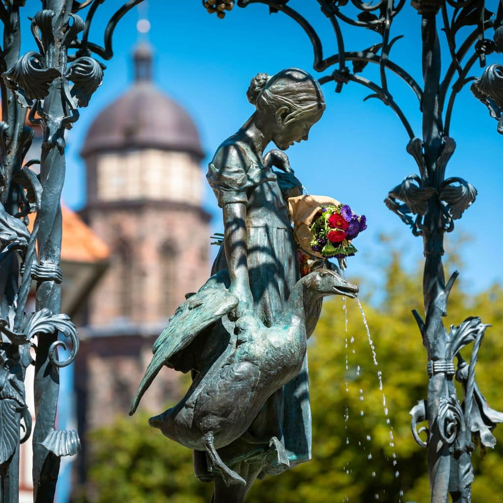

Natural stimulus

⇄

Encoding

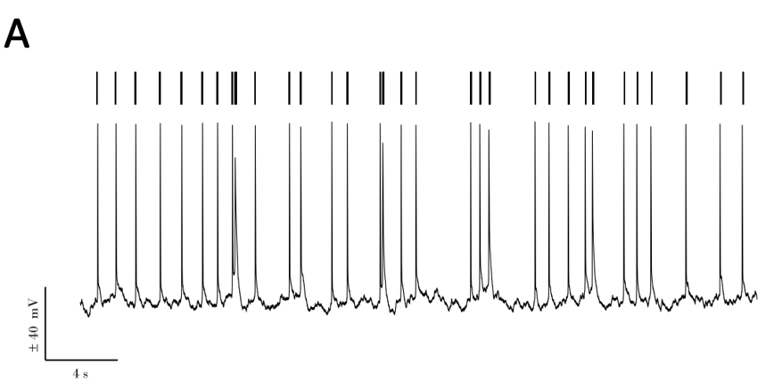

Response

Sharpee et al. (2006), Nawrot MP et al., 2007

## Linear description ?

## Receptive field

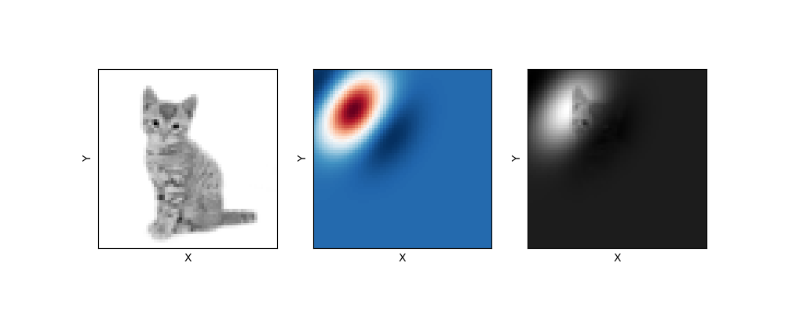

$$\begin{aligned}
\lambda(t)
&= \lambda_0 \\
&\quad +
\underbrace{
\iiint dxdyd\tau\,
\mathcal{K}(x,y,\tau)\,
\mathcal{S}(x,y,t-\tau)
}_{\mathcal{L}}
\end{aligned}$$

## RF estimation using reverse correlation studies

## Questions

- 1. Can computational models help us in modelling and inferring receptive fields?
- 2. What do these models tell us about the complex structure of teh receptive fields?

## Project Objectives

🔗

### Pipeline

Large-scale reverse correlation analysis on recorded neural data — Receptive Field Kit

⚡

### Stimulation

Design, construct and validate a device for neuro-stimulation experiments — HD MANTIS

🧫

### Cultures

Sterile culturing and maintenance of cell cultures for large-scale recordings

## Inferring RF from forward models

LNP spike trains with a ground truth filter

## Inferring RF from forward models - Network models

Using GLMs to recover RF with additional information

## Which Surrogate?

Light sensitized dissociated cortical cultures plated on a multi electrode array

## Chronic light perturbation experiments

[figure not shown]

Light Disco Ver. 1.0

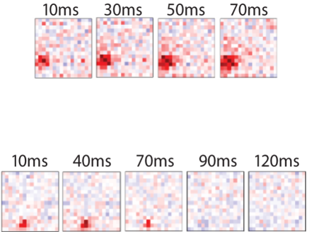

Receptive Field estimates

Dr. Andreas Neef

## Goal : Develop a high resolution optical stimulation system

🔬

### Resolution

Sub-cellular stimulus delivery

🧠

### Recording

Large-scale electrophysiology

⏱️

### Sync

Sub-millisecond synchronization

🧫

### Environment

Incubator compatible

## High Density Multielectrode Array based Neuronal Targeting via Illuminated Stimuli

[figure not shown]

[figure not shown]

[figure not shown]

[figure not shown]

### High Definition OLED Display

[figure not shown]

### Raspberry Pi

[figure not shown]

### Maxwell suite

[figure not shown]

## Optics - Light Power Intensity Measurements

### Response verification

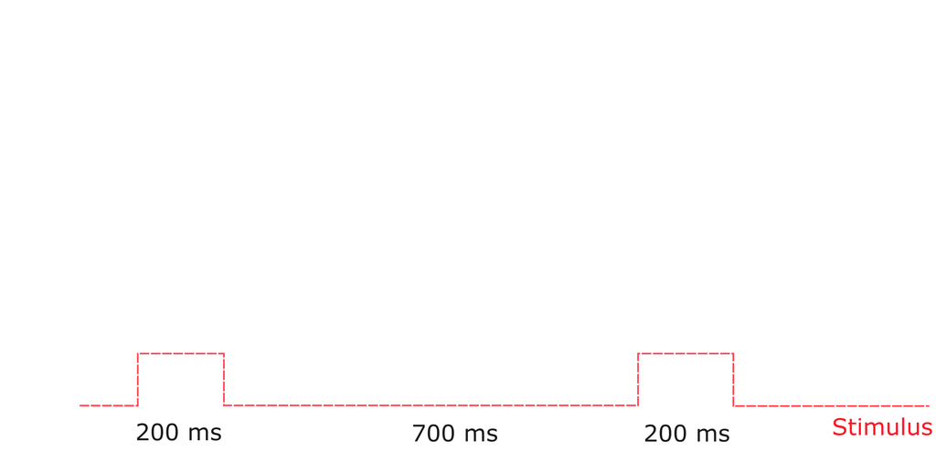

[figure not shown]

E = 0.013 mW/mm2

### Different Lenses

[interactive chart not shown]

## Optics - Resolution Measurements

### On-axis PSF

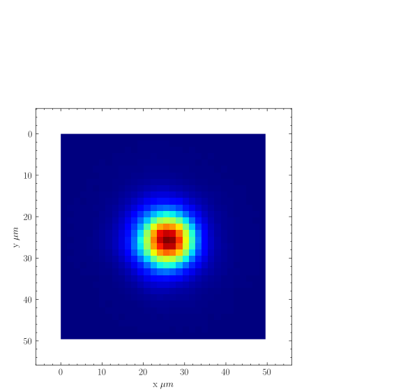

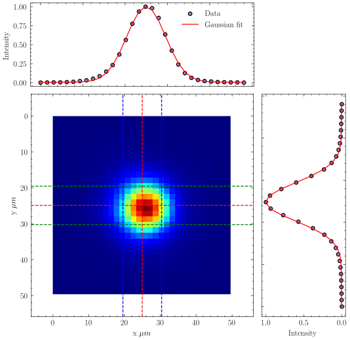

On-axis FWHM : $10.8 \mu m$

### Spatial Inhomogeneity of the PSFs

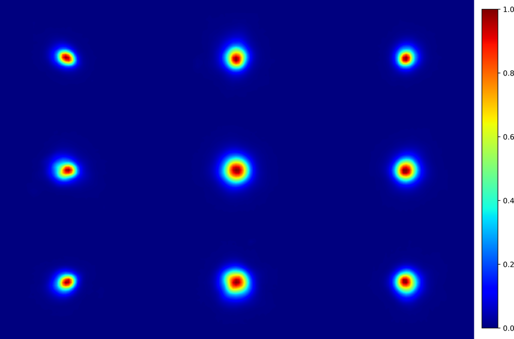

## Software stack - Overview

[figure not shown]

[figure not shown]

[figure not shown]

[figure not shown]

[figure not shown]

[figure not shown]

[figure not shown]